# Regression: Mediation and Moderation

Ziyuan Huang

Last Updated: 2026-01-29

# What is Mediation?

- Refers to a situation when the relationship between a predictor variable and outcome variable can be explained by their relationship to a third variable (the mediator).

> **Plain English:** Mediation is like a “middle man” or a relay race. The predictor passes the baton to the mediator, who then runs to the finish line (the outcome). If the predictor (X) affects the outcome (Y), mediation explains *how* or *why* that happens.

> *Example:* Does stress cause illness? Maybe stress (X) lowers your immune system (Mediator), which then leads to illness (Y). The immune system *mediates* the relationship.

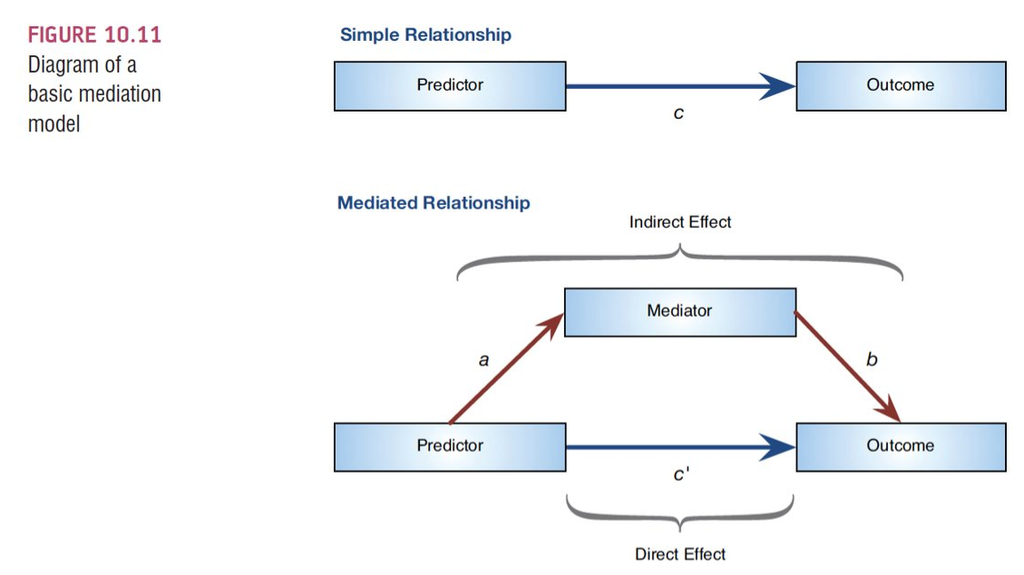

# Baron & Kenny (1986)

- **Mediation** was historically tested through three regression models:
  - Predicting the outcome from the predictor variable.
  - Predicting the mediator from the predictor variable.
  - Predicting the outcome from both the predictor variable and the mediator.

> **State of the Art (2026):** While Baron & Kenny’s steps are great for understanding the *concept*, they are no longer considered sufficient for *testing* mediation in modern analytics. They have low statistical power (high chance of missing a real effect). Today, we focus on the **Indirect Effect** itself, usually tested via **Bootstrapping**.

# Baron & Kenny (1986)

- **Four conditions of mediation (Classic View):**
  - The predictor must significantly predict the outcome variable.*
  - The predictor must significantly predict the mediator.
  - The mediator must significantly predict the outcome variable.
  - The predictor variable must predict the outcome variable less strongly in model 3 than in model 1.

# Baron & Kenny (1986): Limitations

- How much of a reduction in the relationship between the predictor and outcome is necessary to infer mediation?
- People tend to look for a change in significance, which can lead to the ‘all or nothing’ thinking that p-values encourage.
- Two solutions:
  - The Sobel test (Older)
  - **Bootstrapping the indirect effect and confidence intervals (Modern Standard)**

# Sobel Test

- An alternative is to estimate the indirect effect and its significance using the Sobel test (Sobel, 1982).
- If the Sobel test is significant, there is significant mediation.
- We are going to use the Aroian Test version of Sobel which corrects for the standard error of the a and b paths.

> **Note:** The Sobel test assumes that the indirect effect (a*b) is normally distributed. This is often* not* true, especially in smaller samples. This makes the Sobel test “conservative” (harder to find significant results).

# Bootstrapping (The Gold Standard)

- **What is bootstrapping?**
  - A procedure where you run an analysis many times (e.g., 5,000 or 10,000 times) to create an average effect and confidence interval of the effect.
  - Bootstrapped datasets are created by randomly picking a sample from your dataset *with replacement*.
  - Think about this like the lottery, if they put the balls back after every draw.
  - If the confidence interval of the indirect (mediation) effect does not cross zero, then that implies that mediation has occurred.

> **Why it’s better:** Bootstrapping does not assume the data are normally distributed. It builds a distribution based on *your specific data*. This makes it the most accurate and powerful method for testing mediation today.

# Mediation: Data Screening

- Mediation models usually occur in stages - meaning separate models are run with different IV / DV combinations.
- Sometimes people call these “steps”, but do not confuse this with hierarchical regression.
- So, what does that do for data screening?
  - Screen both the IV and the Mediator at the same time predicting the DV.
  - This way you are screening the final anticipated stage of the mediation model and are screening all the variables.
  - You can also use the fake regression procedure to do all three variables at once.

# Mediation: Example

- Does Facebook use mediate the relationship between previous knowledge and exam scores?
- Implying that the overuse of Facebook prevents people from studying, so they do differently on their exam?
- Important not to have missing data, so you are comparing models that all use the same data points.

```r
library(rio)
master <- import("data/mediation.sav")
str(master)
```

```
## 'data.frame':    240 obs. of  3 variables:
##  $ previous: num  3 2 1 1 1 1 1 1 1 1 ...
##   ..- attr(*, "format.spss")= chr "F1.0"
##   ..- attr(*, "display_width")= int 14
##  $ facebook: num  3.67 5 4 4.5 4.5 ...
##   ..- attr(*, "format.spss")= chr "F8.2"
##   ..- attr(*, "display_width")= int 14
##  $ exam    : num  1 1 2 7 6 1 2 1 1 1 ...
##   ..- attr(*, "format.spss")= chr "F8.2"
##   ..- attr(*, "display_width")= int 10
```

```r
summary(master)
```

```
##     previous        facebook          exam
##  Min.   :1.000   Min.   :1.750   Min.   : 1.000
##  1st Qu.:1.000   1st Qu.:3.750   1st Qu.: 1.000
##  Median :1.000   Median :4.250   Median : 1.000
##  Mean   :1.571   Mean   :4.143   Mean   : 1.825
##  3rd Qu.:2.000   3rd Qu.:4.750   3rd Qu.: 2.000
##  Max.   :7.000   Max.   :5.000   Max.   :11.000
##                  NA's   :1
```

```r
master <- na.omit(master)
```

# Mediation: c Path

- The c path: X –> Y:
  $$b = 0.32, t(237)
  = 3.63, p < .001$$

```r
model1 <- lm(exam ~ previous, data = master)
summary(model1)
```

```
##
## Call:
## lm(formula = exam ~ previous, data = master)
##
## Residuals:
##     Min      1Q  Median      3Q     Max
## -1.9092 -0.6477 -0.6477  0.3523  8.4062
##
## Coefficients:
##             Estimate Std. Error t value Pr(>|t|)
## (Intercept)  1.33228    0.16749   7.955 7.37e-14 ***
## previous     0.31539    0.08689   3.630 0.000348 ***
## ---
## Signif. codes:  0 '***' 0.001 '**' 0.01 '*' 0.05 '.' 0.1 ' ' 1
##
## Residual standard error: 1.496 on 237 degrees of freedom
## Multiple R-squared:  0.05266,    Adjusted R-squared:  0.04867
## F-statistic: 13.17 on 1 and 237 DF,  p-value: 0.0003476
```

# Mediation: a Path

- The a path: X –> M:
  $$b = -0.09,
  t(237) = -2.17, p = .031$$

```r
model2 <- lm(facebook ~ previous, data = master)
summary(model2)
```

```
##
## Call:
## lm(formula = facebook ~ previous, data = master)
##
## Residuals:
##      Min       1Q   Median       3Q      Max
## -2.44609 -0.44609  0.05391  0.55391  1.35640
##
## Coefficients:
##             Estimate Std. Error t value Pr(>|t|)
## (Intercept)  4.28817    0.08195  52.330   <2e-16 ***
## previous    -0.09208    0.04251  -2.166   0.0313 *
## ---
## Signif. codes:  0 '***' 0.001 '**' 0.01 '*' 0.05 '.' 0.1 ' ' 1
##
## Residual standard error: 0.732 on 237 degrees of freedom
## Multiple R-squared:  0.01941,    Adjusted R-squared:  0.01527
## F-statistic: 4.692 on 1 and 237 DF,  p-value: 0.03131
```

# Mediation: b, c’ Path

```r
model3 <- lm(exam ~ previous + facebook, data = master)
summary(model3)
```

```
##
## Call:
## lm(formula = exam ~ previous + facebook, data = master)
##
## Residuals:
##     Min      1Q  Median      3Q     Max
## -2.6065 -0.7666 -0.3117  0.3850  7.9999
##
## Coefficients:
##             Estimate Std. Error t value Pr(>|t|)
## (Intercept)  3.93294    0.56791   6.925 4.09e-11 ***
## previous     0.25954    0.08397   3.091  0.00224 **
## facebook    -0.60647    0.12705  -4.773 3.18e-06 ***
## ---
## Signif. codes:  0 '***' 0.001 '**' 0.01 '*' 0.05 '.' 0.1 ' ' 1
##
## Residual standard error: 1.432 on 236 degrees of freedom
## Multiple R-squared:  0.1361, Adjusted R-squared:  0.1288
## F-statistic: 18.59 on 2 and 236 DF,  p-value: 3.194e-08
```

# Mediation: Interpretation

- Previous experience positively impacts exam scores (c path = 0.32).
- Previous experience negatively impacts Facebook time (a path = -0.09).
- Controlling for previous experience, Facebook time negatively impacts exam scores (b path = -0.61).
- Controlling for Facebook scores, previous experience positively impacts exam scores (c’ path = 0.26).
- So, did mediation happen? Is a change from 0.31 to 0.26 important?

# Mediation: Sobel Test

- The Aroian Test: $Z = \frac{a \times b}{\sqrt{b^2 \times SD_a^2 + a^2 \times SD_b^2 + SD_a^2 \times SD_b^2}}$
- If the indirect effect is larger than the error, we would conclude that the addition of the M variable changed the c path.
  - Fill in the correct coefficient numbers
  - Note if you use this code provided and fill in X and M in the correct order, you will not need to change the Sobel code.

```r
#aroian sobel
a <- coef(model2)[2]
b <- coef(model3)[3]
SEa <- summary(model2)$coefficients[2,2]
SEb <- summary(model3)$coefficients[3,2]
zscore <- (a*b)/(sqrt((b^2*SEa^2)+(a^2*SEb^2)+(SEa^2*SEb^2)))
zscore
```

```
## previous
## 1.937494
```

```r
#two tailed test
pnorm(abs(zscore), lower.tail = F)*2
```

```
##   previous
## 0.05268497
```

# Mediation: Sobel Test

- Z = 1.93, p = .053
- We would conclude that no mediation had occurred.

# Mediation: All Together + Bootstrapping

> **State of the Art (2026):** In professional data science settings, while `MeMoBootR` is excellent for learning and quick “all-in-one” analysis, you will often see the `lavaan` package (for Structural Equation Modeling) or the `mediation` package used for complex mediation models. These are the industry standards for publication-quality analysis.

```r
# Ensure a CRAN mirror is set
if(is.null(getOption("repos"))) {
  options(repos = c(CRAN = "https://cloud.r-project.org"))
}

# Install devtools if missing
if (!requireNamespace("devtools", quietly = TRUE)) {
  install.packages("devtools")
}

# Install MeMoBootR if missing
if (!requireNamespace("MeMoBootR", quietly = TRUE)) {
  message("Installing MeMoBootR from GitHub...")
  tryCatch({
    devtools::install_github("doomlab/MeMoBootR", force = TRUE, upgrade = "never", quiet = TRUE)
  }, error = function(e) {
    warning("Failed to install MeMoBootR: ", e$message)
  })
}
```

```
## Installing MeMoBootR from GitHub...
```

```r
# Load the package
if (require("MeMoBootR")) {
  #no missing data allowed
  med_results <- mediation1(y = "exam",
                            x = "previous",
                            m = "facebook",
                            df = master)
} else {
  message("MeMoBootR package is not available. Mediation results cannot be generated.")
  # Create a dummy object to prevent future errors
  med_results <- list(
    datascreening = list(fulldata = NULL, correl = NULL, linearity = NULL, normality = NULL, homogen = NULL),
    model1 = NULL, model2 = NULL, model3 = NULL,
    indirect.effect = NULL, z.score = NULL, p.value = NULL,
    boot.results = NULL, boot.ci = NULL, diagram = NULL
  )
}
```

```
## MeMoBootR package is not available. Mediation results cannot be generated.
```

# Mediation: MeMoBootR

```r
head(med_results$datascreening$fulldata)
```

[output not shown]

```r
med_results$datascreening$correl
```

[output not shown]

```r
med_results$datascreening$linearity
```

[output not shown]

```r
med_results$datascreening$normality
```

[output not shown]

```r
med_results$datascreening$homogen
```

[output not shown]

# Mediation: MeMoBootR

- For each of our stages of mediation, you can print out the models:

```r
summary(med_results$model1)
```

```
## Length  Class   Mode
##      0   NULL   NULL
```

```r
summary(med_results$model2)
```

```
## Length  Class   Mode
##      0   NULL   NULL
```

```r
summary(med_results$model3)
```

```
## Length  Class   Mode
##      0   NULL   NULL
```

# Mediation: MeMoBootR

```r
med_results$indirect.effect
```

[output not shown]

```r
med_results$z.score
```

[output not shown]

```r
med_results$p.value
```

[output not shown]

# Mediation: MeMoBootR

```r
med_results$boot.results
```

[output not shown]

```r
med_results$boot.ci
```

[output not shown]

```r
med_results$diagram
```

[output not shown]

# Moderation

- The combined effect of two variables on another is known conceptually as **moderation**, and in statistical terms as an **interaction effect**.

> **Plain English:** Moderation is the “It Depends” variable. If I ask, “Does eating pizza make you happy?”, you might say, “It depends on if I’m hungry.” Hunger is the moderator.
> - In statistics, we say the relationship between X and Y *changes* depending on the level of Z.
> - Graphically, this looks like **non-parallel lines**. If the lines cross or fan out, you have an interaction.
- Do violent video games make people aggressive?
  - DV: Aggression
  - IV:
    - Callous unemotional traits
    - Number of hours spent playing video games per week
    - Interaction

# Conceptual Moderation Model

- If callous-unemotional traits were a moderator then we’re saying that the strength or direction of the relationship between game playing and aggression depends on the strength of callous-unemotional traits.

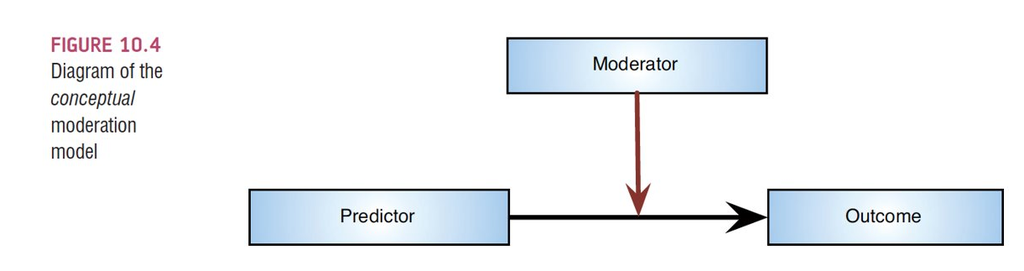

# Conceptual Moderation Model

- If the X variable was categorical, you are basically checking if the separate groups (levels) have different slopes for the non-categorical variable.

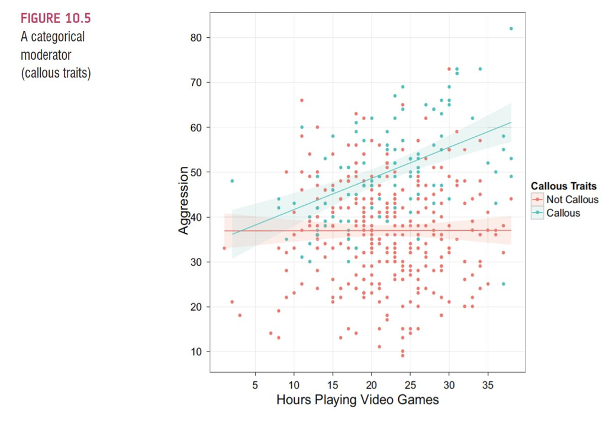

# Conceptual Moderation Model

- However, if X is continuous, we have to find a new way to figure out the shape of the interaction.

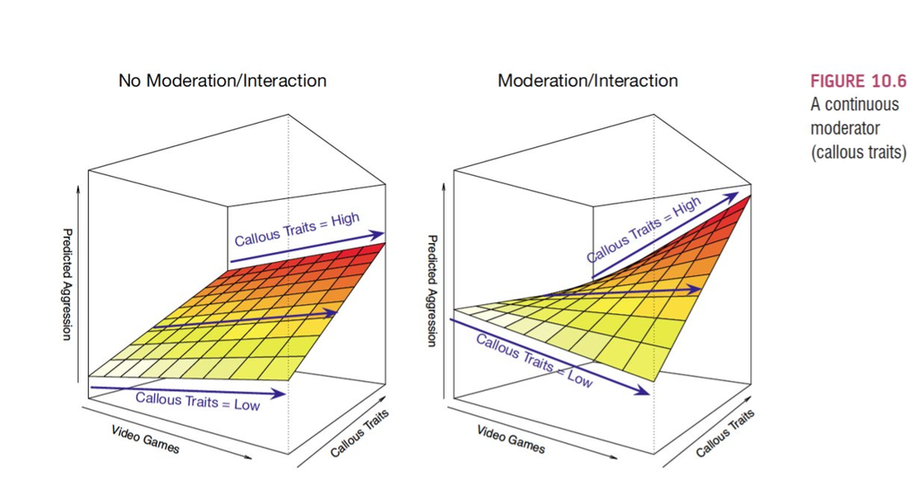

# Statistical Moderation Model

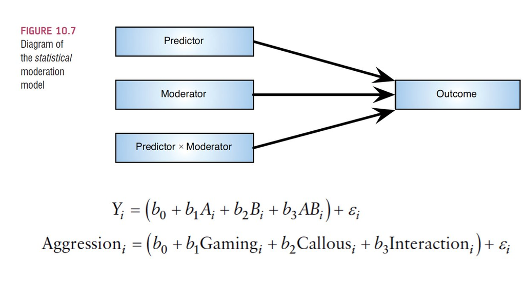

# Centering variables

- The interaction term makes the *b*s for the main predictors uninterpretable in many situations.
- Centering refers to the process of transforming a variable into deviations around a fixed point.
- Centering solves two problems:
  - Interpretation
  - Multicollinearity

> **Plain English:** Why do we center?
> 1. **Interpretation:** In regression, the Intercept is the value of Y when X is 0. If X is “Heart Rate”, 0 is dead. That’s not useful. If we center X (subtract the mean), then 0 becomes the “Average Heart Rate”. Now the intercept is the score for the *average person*.
> 2. **Multicollinearity:** X and X*Z are highly correlated because X is inside X*Z. Centering breaks this correlation, making the math more stable.

# Centering variables

- Easiest way to center to make them useful:
  - Score - Mean for that variable.
  - What does that do?
- Centered variables for main effects have two interpretations
  - Effect of that predictor at the mean value for the sample
  - Average effect of the predictor across a range of scores for the other predictor

# Moderation: Simple Slopes

- If the interaction is significant, then you usually ignore the main effects (each variable by itself).
- So what do I do if my interaction is significant? **A simple slope analysis**
- If variables are categorical, then you are simply looking at the differences across one variable or another

# Moderation: Simple Slopes

- For continuous variables, you “create” low, average, and high groups.
  - Low groups are people who are one SD below the mean
  - Average groups are people are at the mean
  - High groups are people who are one SD above the mean
  - However, creating groups is backwards from what you think.

# Moderation: Simple Slopes

- We are examining the interaction between hours of video games and unemotional traits to predict aggression
- Think about which variable you want to know the differences in (i.e., low, average, high).
- So at different levels of callousness, we want to examine the relationship between hours of video games and aggression.

```r
master <- import("data/moderation.sav")
str(master)
```

```
## 'data.frame':    442 obs. of  4 variables:
##  $ ID        : num  69 55 7 96 130 124 72 139 102 179 ...
##   ..- attr(*, "label")= chr "Case ID"
##   ..- attr(*, "format.spss")= chr "F3.0"
##  $ Aggression: num  13 38 30 23 25 46 41 22 35 23 ...
##   ..- attr(*, "label")= chr "Agression"
##   ..- attr(*, "format.spss")= chr "F2.0"
##  $ Vid_Games : num  16 12 32 10 11 29 23 15 20 20 ...
##   ..- attr(*, "label")= chr "Video Games (Hours per week)"
##   ..- attr(*, "format.spss")= chr "F2.0"
##  $ CaUnTs    : num  0 0 0 1 1 1 2 3 3 3 ...
##   ..- attr(*, "label")= chr "Callous Unemotional Traits"
##   ..- attr(*, "format.spss")= chr "F2.0"
```

# Moderation: Centering

- Center your variables using scale()
  - Using scale = F turns off dividing by SD, which would create z-scores.
  - You can use z-score centering if you wanted the coefficients to be beta. It is likely easier to interpret the b values though.

```r
#center the X and M variable (NOT THE DV)
#when you create these use the final dataset
master$zvid = scale(master$Vid_Games, scale = F) #mean center, not z score
master$zcal = scale(master$CaUnTs, scale = F)
```

# Moderation: Running

- For data screening, we would screen the model with the interaction, and all other considerations are the same as regression.
- Run the model:
  - You do not have to create an interaction column, to multiply does that automatically for you.
  - Also includes the main effects of each variable by itself.

```r
#run the model to see if the moderation is significant
#use the z score variables!
#be sure to do X*M so the graph is right
modmodel <- lm(Aggression ~ zvid*zcal, data = master)
```

# Moderation: Interpretation

- Overall model is significant, $F(3, 438) = 88.46, p < .001, R^2 = .38$
- Interaction effect is significant, $b = 0.03, t(438) = 3.88, p < .001$

```r
summary(modmodel)
```

```
##
## Call:
## lm(formula = Aggression ~ zvid * zcal, data = master)
##
## Residuals:
##      Min       1Q   Median       3Q      Max
## -29.7144  -6.9087  -0.1923   6.9036  29.2290
##
## Coefficients:
##              Estimate Std. Error t value Pr(>|t|)
## (Intercept) 39.967108   0.475057  84.131  < 2e-16 ***
## zvid         0.169625   0.068473   2.477 0.013616 *
## zcal         0.760093   0.049458  15.368  < 2e-16 ***
## zvid:zcal    0.027062   0.006981   3.877 0.000122 ***
## ---
## Signif. codes:  0 '***' 0.001 '**' 0.01 '*' 0.05 '.' 0.1 ' ' 1
##
## Residual standard error: 9.976 on 438 degrees of freedom
## Multiple R-squared:  0.3773, Adjusted R-squared:  0.373
## F-statistic: 88.46 on 3 and 438 DF,  p-value: < 2.2e-16
```

# Moderation: Simple Slopes

- So, how do we create groups when we have a continuous variable?
  - Most people look at “low” as one SD below the mean and “high” as one SD above the mean.
  - Lots of combinations are possible though.

# Moderation: Simple Slopes

- Create the low and high versions of the M variable (callousness in this example)
  - Low created by ADDING a SD
  - High created by SUBTRACTING a SD
  - The rule is that we have to bring them to the middle because we centered so that zero is the middle

```r
#create the low and high z score variables
master$zcallow <- master$zcal + sd(master$zcal) #bring them up
master$zcalhigh <- master$zcal - sd(master$zcal) #bring them down
summary(master)
```

```
##        ID          Aggression      Vid_Games         CaUnTs
##  Min.   :  1.0   Min.   : 9.00   Min.   : 1.00   Min.   : 0.0
##  1st Qu.:111.2   1st Qu.:32.00   1st Qu.:17.00   1st Qu.:11.0
##  Median :221.5   Median :40.00   Median :22.00   Median :18.0
##  Mean   :221.5   Mean   :40.05   Mean   :21.84   Mean   :18.6
##  3rd Qu.:331.8   3rd Qu.:48.00   3rd Qu.:26.00   3rd Qu.:26.0
##  Max.   :442.0   Max.   :82.00   Max.   :38.00   Max.   :43.0
##            zvid.V1                     zcal.V1
##  Min.   :-2.08438914027e+01   Min.   :-18.595022624400
##  1st Qu.:-4.84389140271e+00   1st Qu.: -7.595022624430
##  Median : 1.56108597285e-01   Median : -0.595022624434
##  Mean   : 1.00000000000e-15   Mean   :  0.000000000000
##  3rd Qu.: 4.15610859729e+00   3rd Qu.:  7.404977375570
##  Max.   : 1.61561085973e+01   Max.   : 24.404977375600
##         zcallow.V1               zcalhigh.V1
##  Min.   :-8.97732952676   Min.   :-28.21271572210
##  1st Qu.: 2.02267047324   1st Qu.:-17.21271572210
##  Median : 9.02267047324   Median :-10.21271572210
##  Mean   : 9.61769309767   Mean   : -9.61769309767
##  3rd Qu.:17.02267047320   3rd Qu.: -2.21271572211
##  Max.   :34.02267047320   Max.   : 14.78728427790
```

# Moderation: Simple Slopes

- Then run the model with the new low and high versions of the variable.
- What do I do with that?
- You look at the other variable because the coefficients for M and X*M will not change.

```r
#run the models
#be sure to X*M
modmodellow <- lm(Aggression ~ zvid*zcallow, data = master)
modmodelhigh <- lm(Aggression ~ zvid*zcalhigh, data = master)
```

# Moderation: Simple Slopes

- At low levels of callousness, video game hours is unrelated to aggression, b = -0.09 …

```r
summary(modmodellow) #low slope
```

```
##
## Call:
## lm(formula = Aggression ~ zvid * zcallow, data = master)
##
## Residuals:
##      Min       1Q   Median       3Q      Max
## -29.7144  -6.9087  -0.1923   6.9036  29.2290
##
## Coefficients:
##               Estimate Std. Error t value Pr(>|t|)
## (Intercept)  32.656771   0.672018  48.595  < 2e-16 ***
## zvid         -0.090651   0.099105  -0.915 0.360854
## zcallow       0.760093   0.049458  15.368  < 2e-16 ***
## zvid:zcallow  0.027062   0.006981   3.877 0.000122 ***
## ---
## Signif. codes:  0 '***' 0.001 '**' 0.01 '*' 0.05 '.' 0.1 ' ' 1
##
## Residual standard error: 9.976 on 438 degrees of freedom
## Multiple R-squared:  0.3773, Adjusted R-squared:  0.373
## F-statistic: 88.46 on 3 and 438 DF,  p-value: < 2.2e-16
```

# Moderation: Simple Slopes

- At average levels of callousness, hours of video games predicts increasing aggression, b = 0.17 …

```r
summary(modmodel) #average slope
```

```
##
## Call:
## lm(formula = Aggression ~ zvid * zcal, data = master)
##
## Residuals:
##      Min       1Q   Median       3Q      Max
## -29.7144  -6.9087  -0.1923   6.9036  29.2290
##
## Coefficients:
##              Estimate Std. Error t value Pr(>|t|)
## (Intercept) 39.967108   0.475057  84.131  < 2e-16 ***
## zvid         0.169625   0.068473   2.477 0.013616 *
## zcal         0.760093   0.049458  15.368  < 2e-16 ***
## zvid:zcal    0.027062   0.006981   3.877 0.000122 ***
## ---
## Signif. codes:  0 '***' 0.001 '**' 0.01 '*' 0.05 '.' 0.1 ' ' 1
##
## Residual standard error: 9.976 on 438 degrees of freedom
## Multiple R-squared:  0.3773, Adjusted R-squared:  0.373
## F-statistic: 88.46 on 3 and 438 DF,  p-value: < 2.2e-16
```

# Moderation: Simple Slopes

- At high levels of callousness, the strength of hours of video games predicting aggression is the strongest, b = 0.43 …

```r
summary(modmodelhigh) #high slope
```

```
##
## Call:
## lm(formula = Aggression ~ zvid * zcalhigh, data = master)
##
## Residuals:
##      Min       1Q   Median       3Q      Max
## -29.7144  -6.9087  -0.1923   6.9036  29.2290
##
## Coefficients:
##                Estimate Std. Error t value Pr(>|t|)
## (Intercept)   47.277446   0.672520  70.299  < 2e-16 ***
## zvid           0.429901   0.092577   4.644 4.53e-06 ***
## zcalhigh       0.760093   0.049458  15.368  < 2e-16 ***
## zvid:zcalhigh  0.027062   0.006981   3.877 0.000122 ***
## ---
## Signif. codes:  0 '***' 0.001 '**' 0.01 '*' 0.05 '.' 0.1 ' ' 1
##
## Residual standard error: 9.976 on 438 degrees of freedom
## Multiple R-squared:  0.3773, Adjusted R-squared:  0.373
## F-statistic: 88.46 on 3 and 438 DF,  p-value: < 2.2e-16
```

# Moderation: Simple Slopes

- Significant interactions will create fan effects of slopes that either get stronger/weaker in strength or switch directions.
- Here, we find that increasing levels of callousness leads to increasing effects of video game time on aggression.

# Moderation: Graphing

- We can use the ggplot to create a graph of the moderation effect.
- But we are going to manually draw the lines on a scatterplot graph.

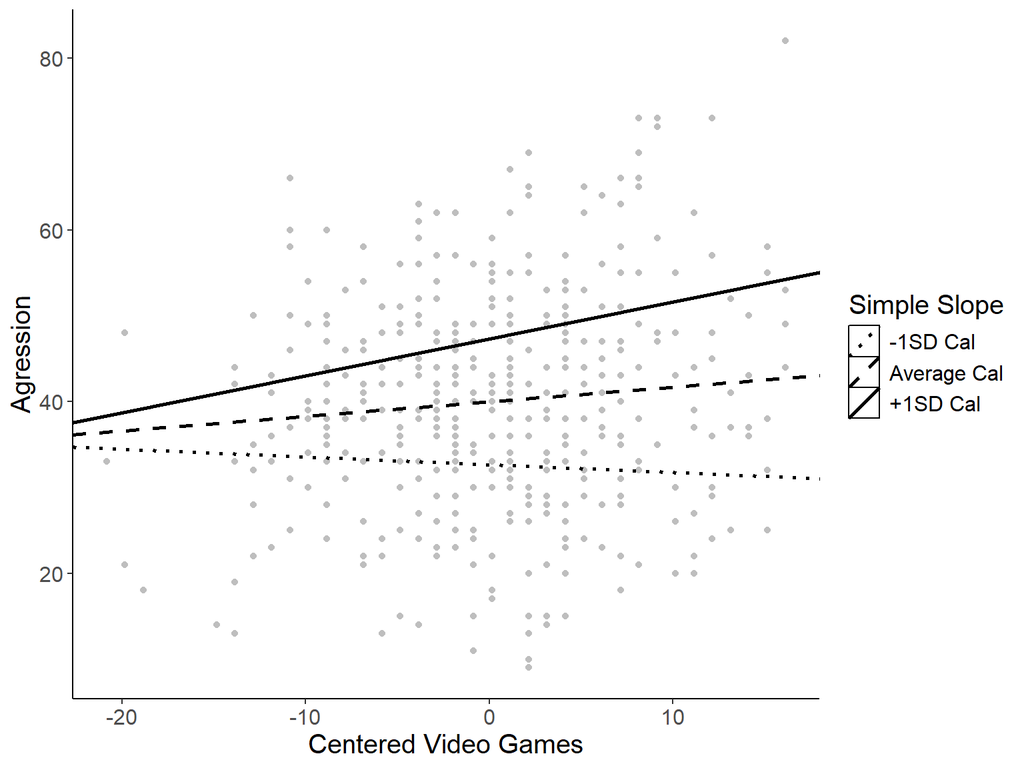

```r
library(ggplot2)
cleanup <- theme(panel.grid.major = element_blank(),
                panel.grid.minor = element_blank(),
                panel.background = element_blank(),
                axis.line.x = element_line(color = "black"),
                axis.line.y = element_line(color = "black"),
                legend.key = element_rect(fill = "white"),
                text = element_text(size = 15))

modgraph <- ggplot(master, aes(zvid, Aggression))

##change Cal to the new moderator label
##change xlab for the new X label
modgraph +
  xlab("Centered Video Games") +
  geom_point(color = "gray") +
  geom_abline(aes(intercept = modmodellow$coefficients[1],
                  slope = modmodellow$coefficients[2],
                  linetype = "-1SD Cal"), size = 1) +
  geom_abline(aes(intercept = modmodel$coefficients[1],
                  slope = modmodel$coefficients[2],
                  linetype = "Average Cal"), size = 1) +
  geom_abline(aes(intercept = modmodelhigh$coefficients[1],
                  slope = modmodelhigh$coefficients[2],
                  linetype = "+1SD Cal"), size = 1) +
  scale_linetype_manual(values = c("dotted", "dashed", "solid"),
                        breaks = c("-1SD Cal", "Average Cal", "+1SD Cal"),
                        name = "Simple Slope") +
  cleanup
```

# Moderation: MeMoBootR

```r
if (exists("moderation1")) {
  mod_model <- moderation1(y = "Aggression",
                           x = "Vid_Games",
                           m = "CaUnTs",
                           df = master)
} else {
  mod_model <- list(
    datascreening = list(fulldata = NULL),
    model1 = NULL,
    interpretation = "MeMoBootR not available.",
    graphslopes = NULL
  )
}
```

# Moderation: MeMoBootR

```r
#data screening
head(mod_model$datascreening$fulldata)
```

[output not shown]

```r
#mod_model$datascreening$correl
#mod_model$datascreening$linearity
#mod_model$datascreening$normality
#mod_model$datascreening$homogen

#models
summary(mod_model$model1)
```

```
## Length  Class   Mode
##      0   NULL   NULL
```

```r
#summary(mod_model$model1low)
#summary(mod_model$model1high)
mod_model$interpretation
```

```
## [1] "MeMoBootR not available."
```

```r
#graphs
mod_model$graphslopes
```

[output not shown]

# Summary

- In this lecture, we have covered:
  - Mediation
  - Moderation
  - Special packages for these models
  - Follow ups for these models